# Introduction to R graphics - `ggplot2` version

Original Contributors: Gloria Li, Dean Attali (heatmap). Modified by Alice Zhu.

This seminar will primarily draw on functions in the add-on package `ggplot2`. This package is quite different from base R graphics; it implements the **Grammar of Graphics**, i.e. *gg*. It might seem daunting at first, but don’t worry, once you get used to this idea, it is a fairly easy way to construct complex graphics.

If you have not done so already, install this package:

```r
# if you haven't installed ggplot2, type:
# install.packages("ggplot2")
```

and load it:

```r
library(ggplot2)
```

## Basic concepts

- **Layer**: The most important concept of `ggplot2` is that graphics are built of different *layers*. This includes anything from the data used, the coordinate system, the axis labels, the plot’s title etc. This layered grammar is perhaps the most powerful feature of `ggplot2`. It allows us to build complex graphics by adding more and more layers to the basic graphics while each layer is simple enough to construct. Layers can contain one or more components such as data and aesthetic mapping, geometries, statistics, scaling etc. We will talk about some most common components next.
- **Aesthetics**: They are graphic elements mapped to data defined by `aes()`. Some of the common aesthetics we usually define are: x-y positions, color, size, shape, linetype etc. Beginners are usually easily confused between aesthetics and geometries. An easy way to distinguish is that you are always trying to assign (*map*) **data** to some graphic elements in aesthetics, while in geometries you don’t feed in any information on the data. It will become clear with some examples later
- **Geometries**: These are the actual graphic elements used to plot, like points / lines / bars etc. These functions usually start with `geom_` and their names are usually self-explanatory. You can also specify color and other graphic elements in these functions, but it will be a single value that’s applied to the entire data. Here is a simple way to see what geometries functions are available:

```r
apropos("^geom_")
```

```
##  [1] "geom_abline"     "geom_area"       "geom_bar"
##  [4] "geom_bin2d"      "geom_blank"      "geom_boxplot"
##  [7] "geom_contour"    "geom_crossbar"   "geom_density"
## [10] "geom_density2d"  "geom_dotplot"    "geom_errorbar"
## [13] "geom_errorbarh"  "geom_freqpoly"   "geom_hex"
## [16] "geom_histogram"  "geom_hline"      "geom_jitter"
## [19] "geom_line"       "geom_linerange"  "geom_map"
## [22] "geom_path"       "geom_point"      "geom_pointrange"
## [25] "geom_polygon"    "geom_quantile"   "geom_raster"
## [28] "geom_rect"       "geom_ribbon"     "geom_rug"
## [31] "geom_segment"    "geom_smooth"     "geom_step"
## [34] "geom_text"       "geom_tile"       "geom_violin"
## [37] "geom_vline"
```

- **Statistics**: These provide a simple and powerful way to summarize your data and present calculated statistics on the plot, like add a regression line, a smoothed curve, calculate density curve etc. For a full list, see below. You can see some of the functions look very similar to some `geom` functions. Indeed these two categories are not mutually exclusive. Some `geom` functions implemented statistical calculation and `stat` functions also come with default geometries.

```r
apropos("^stat_")
```

```
##  [1] "stat_abline"      "stat_bin"         "stat_bin2d"
##  [4] "stat_bindot"      "stat_binhex"      "stat_boxplot"
##  [7] "stat_contour"     "stat_density"     "stat_density2d"
## [10] "stat_ecdf"        "stat_ellipse"     "stat_function"
## [13] "stat_hline"       "stat_identity"    "stat_qq"
## [16] "stat_quantile"    "stat_smooth"      "stat_spoke"
## [19] "stat_sum"         "stat_summary"     "stat_summary_hex"
## [22] "stat_summary2d"   "stat_unique"      "stat_vline"
## [25] "stat_ydensity"
```

- **Scale**: Another powerful feature to alter the default scale to x-y axes, e.g. do a log transformation, instead of the traditional 2-step approach of transforming the data first and then plot it. You can also do more advanced customization to features like color, fill, etc. with these functions. Functions available are

```r
apropos("^scale_")
```

```
##  [1] "scale_alpha"               "scale_alpha_continuous"
##  [3] "scale_alpha_discrete"      "scale_alpha_identity"
##  [5] "scale_alpha_manual"        "scale_area"
##  [7] "scale_color_brewer"        "scale_color_continuous"
##  [9] "scale_color_discrete"      "scale_color_distiller"
## [11] "scale_color_gradient"      "scale_color_gradient2"
## [13] "scale_color_gradientn"     "scale_color_grey"
## [15] "scale_color_hue"           "scale_color_identity"
## [17] "scale_color_manual"        "scale_colour_brewer"
## [19] "scale_colour_continuous"   "scale_colour_discrete"
## [21] "scale_colour_distiller"    "scale_colour_gradient"
## [23] "scale_colour_gradient2"    "scale_colour_gradientn"
## [25] "scale_colour_grey"         "scale_colour_hue"
## [27] "scale_colour_identity"     "scale_colour_manual"
## [29] "scale_fill_brewer"         "scale_fill_continuous"
```

[output cut: 20 more lines]

- **Facetting**: This is very similar to the use of `|` in `lattice` to create separate panels according to some factor. There are two functions: `facet_wrap` for separating on one factor, and `facet_grid` for using two factors. We will cover some examples later.

As you can see, there are a lot of functions available in `ggplot2`. We can only cover some most frequently used ones in this seminar. Check out R help file if you want more information on some particular functions. For more detailed information on `ggplot2`, see links to this book: *ggplot2: Elegant Graphics for Data Analysis* by Hadley Wickham on Jenny’s [resource](http://www.stat.ubc.ca/~jenny/resources.html) page.

Now, let’s try to recreate some of the `lattice` plots with `ggplot2`.

> Remember you may need to edit the file paths below, to reflect your working directory and local file storage choices.

We will still work with the `photoRec` dataset, containing “gene expression profiles of purified photoreceptors at distinct developmental stages and from different genetic backgrounds”. If you need a reminder of what this dataset contains, read the [README](https://github.com/STAT540-UBC/STAT540-UBC.github.io/tree/master/examples/photoRec) file.

We load this mini dataset from a saved R object, in order to preserve factor levels that were set rationally (and non-alphabetically) during data cleaning and pre-processing. This rds file could be retrieved from [HERE](https://github.com/STAT540-UBC/STAT540-UBC.github.io/blob/master/examples/photoRec/data/GSE4051_MINI.rds). Save this rds file in your current working directory.

```r
# you may need to modify the file name inside readRDS() in order to access your saved rds
# file, such as adding the subdirectory name where it is stored
kDat <- readRDS("GSE4051_MINI.rds")
str(kDat)
```

```
## 'data.frame':    39 obs. of  7 variables:
##  $ sidChar   : chr  "Sample_20" "Sample_21" "Sample_22" "Sample_23" ...
##  $ sidNum    : num  20 21 22 23 16 17 6 24 25 26 ...
##  $ devStage  : Factor w/ 5 levels "E16","P2","P6",..: 1 1 1 1 1 1 1 2 2 2 ...
##  $ gType     : Factor w/ 2 levels "wt","NrlKO": 1 1 1 1 2 2 2 1 1 1 ...
##  $ crabHammer: num  10.22 10.02 9.64 9.65 8.58 ...
##  $ eggBomb   : num  7.46 6.89 6.72 6.53 6.47 ...
##  $ poisonFang: num  7.37 7.18 7.35 7.04 7.49 ...
```

```r
table(kDat$devStage)
```

```
##
##     E16      P2      P6     P10 4_weeks
##       7       8       8       8       8
```

```r
table(kDat$gType)
```

```
##
##    wt NrlKO
##    20    19
```

```r
with(kDat, table(devStage, gType))
```

```
##          gType
## devStage  wt NrlKO
##   E16      4     3
##   P2       4     4
##   P6       4     4
##   P10      4     4
##   4_weeks  4     4
```

We see there are 39 samples (rows or observations). We have

It’s pretty clear the intent was to have 4 mice at each combination of genotype and developmental stage, but there was some mishap for the embryonic knockouts, i.e. E16-NrlKO, where we only have data from 3 mice.

## qplot

`qplot` is a function in `ggplot2` for quick plots. Its usage is very similar to the `plot` functions, so people who are used to base graphics can pick it up in no time. Here, let’s see a quick example of scatter plots with qplot.

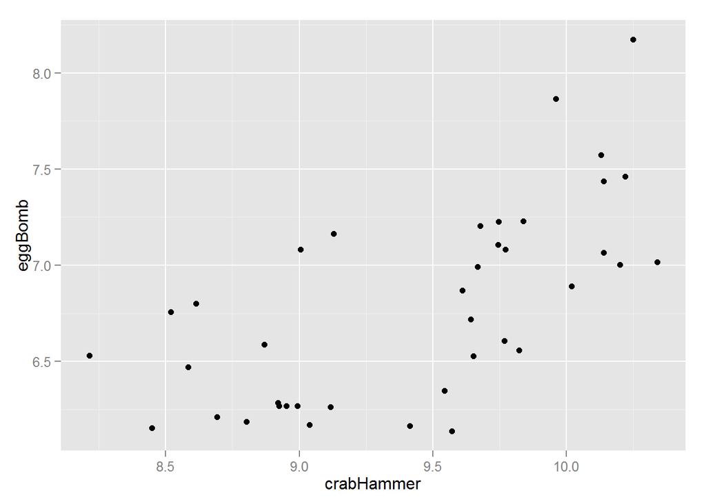

```r
qplot(crabHammer, eggBomb, data = kDat)
```

> With `qplot`, you can quickly generate plots while still be able to use more powerful `ggplot2` features with `geom` and `stat` arguments. See `?qplot` for details. But for more sophisticated plots and improved readability, it’d be better to use the *layer-by-layer* approach below.